Vivek Katial

08/09/2021

- Check out the slides at https://tinyurl.com/vk-gdi-ethics

# Introduction

## About Me

- Disclaimer: **I am not an expert in ethics and philosophy**
- Vivek Katial (vkatial@student.unimelb.edu.au)
- PhD Candidate (Optimisation on Quantum Computers)
- Data Scientist (5 years - Quantiful, Multitudes)
- I love traveling and trying new types of food and meeting interesting people

[figure not shown]

## What are / is ethics?

- The word “Ethics” is derived from the Greek word Ethos, meaning habit or custom.
- Ethics help us distinguish between right and wrong.
- Many schools of thoughts that philosophers have argued over for centuries.
- We are going to assume that whatever there is social consensus on today, is our view on ethics.

## Robert McDaniel

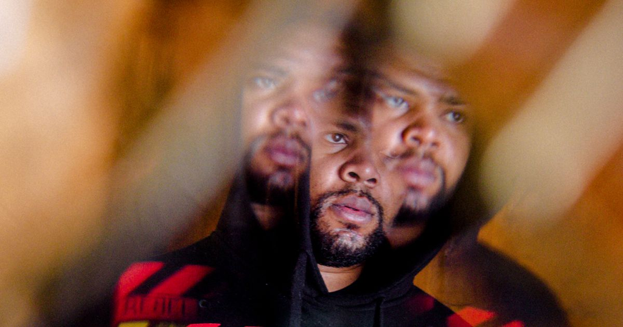

## Predictive Policing

[figure not shown]

## Why do we need to consider ethics in Data Science?

- Fastest growing industry, expected to continue
- Often undesirable consequence can occur. Especially in relation to, privacy, fairness, etc.
- Considering *ethics* provides us a framework to decide what is “OK” to do.

## Agenda

- Data Governance
- Bias
- Data Collection
- Model Building

# Data Governance

- Privacy
- Anonymity

## Privacy

- Handling data needs to respect confidentiality and anonymity
- How do we avoid harm that can occur due to data about us being collected, linked and analysed?
- Internet archives hold information forever

## Privacy - Collection vs Use

- Your ID is taken at a club (Name, address, age)
  - How is this data being used?
  - Is this data stored or sold elsewhere?

## Anonymity

[figure not shown]

## Anonymity

- Some anonymous services **do** exist:
  - Using `tor` the onion browser
  - One can pay using Bitcoin, or other crypto currencies
- Most services require some sense of ID

# Algorithimic Bias

## Algorithimic Bias

What does bias actually mean?

## Algorithimic Bias

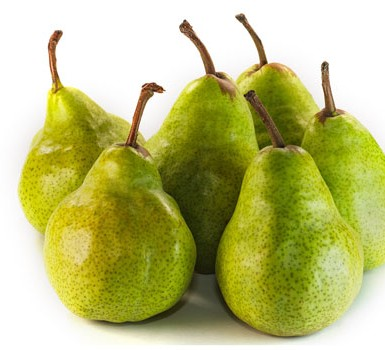

## Algorithimic Bias

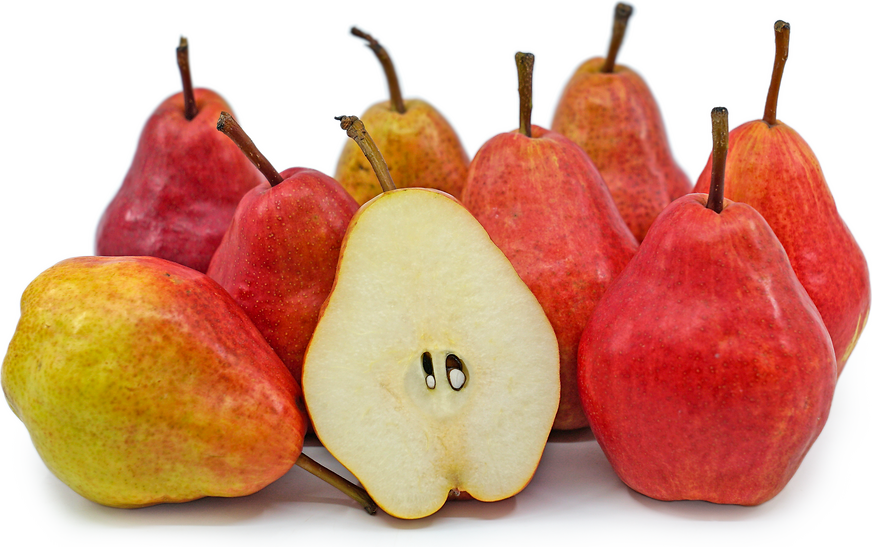

- Red Pear, Read Sliced Pair

## Bias

- Humans label and categorise the world to reduce complex sensory inputs into **simple** groups that we can understand
- For everything, our minds create ‘typical’ representations of a concept or objects
- We thus notice “atypical things”
- **Biases** and **stereotypes** arise when particular labels and features confound our decisions

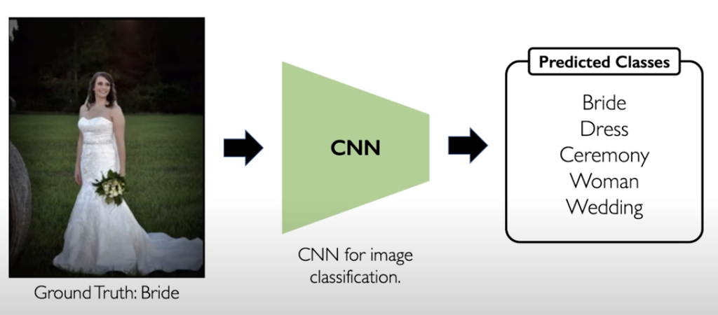

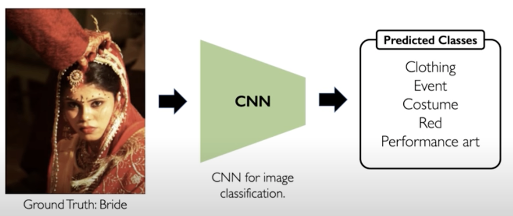

## Understanding why?

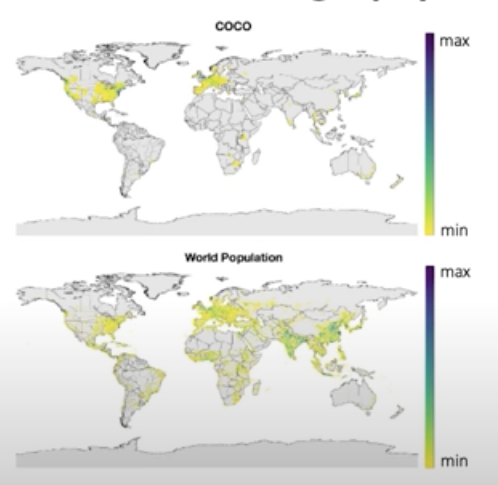

## The Machine Learning Lifecycle

- Data collection and preparation
- Feature engineering and selection
- Model formulation and training
- Model deployment and evaluation
- Interpretation and decisions

## Data Collection

- Data selection does not reflect real-world distribution
- Frequency in training data distributed differently
- Model performance skews to perform better on classes present in the data

## Data Collection

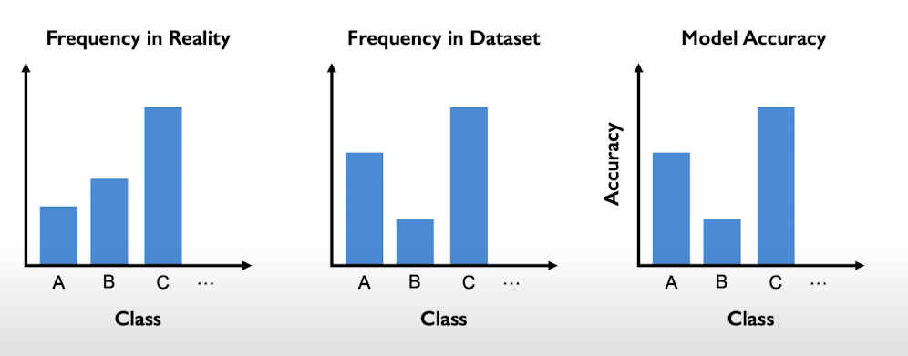

## Data Collection

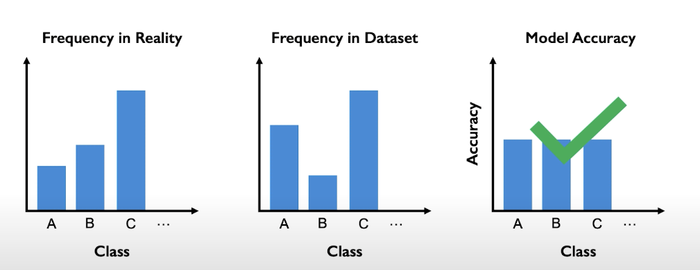

## Mitigation

- Batch Selection
  - Feed samples to the training in balanced manner
- Adjust cost function
- Oversample datapoints from the lower dataset

## Modelling and Feature Engineering

- Bias Mitigation
  - Bias data, model
  - Remove aspects/features that are causing bias (LIME)
- Inclusion
  - Biased Model, dataset
  - Add signal to features that improve fairness

## Evaluation

- Use balanced datasets for evaluation
- Compare accuracy to de-bias models
- Performance metric should be the error (between different subclasses)
- Measure distribution shifts

## Conclusions

- Follow AI Best practices
- Dataset Docs (Gebru 2018)
- Model Reporting and Curation
- Transparency and reproducibility
- R&D in algorithm research

## Extra Links / Resources

# Thank You!

vivek@gooddatainstitute.com